# Economic Data 2026 - Labs

Week 1

**Aims:** In this lab you will set up the software used in this course and learn the basics of working with data in R. By the end you should be able to describe what a dataframe is, access data within one, and produce a simple visualization.

## Part 1: Getting started with RStudio

RStudio is the primary tool we will use to work with data throughout this course. It provides a structured environment for loading, manipulating, and visualizing large datasets.

- Open RStudio. If you are using your own computer, install R and RStudio from [posit.co/downloads](https://posit.co/downloads/).
- Download `intro_R.R` from Blackboard. Open it in RStudio via **File > Open File**, then navigate to the folder where you saved it.
- Run each line in the script and make sure you understand what each command does and what objects it creates. To run a line, place your cursor on it and press `Ctrl+Enter` (or `Cmd+Enter` on Mac).

## Part 2: Objects in R

In this exercise you will analyse a dataset of GDP per capita for the United Kingdom from 2014 to 2018.

- Create a new R script and save it on your computer: **File > New File > R Script**.
- Assign the following values to a vector named `gdp_pc`: `36436`, `36941`, `37334`, `37782`, `38058`. **Hint:** Use `c()` to construct a vector — see line 33 of `intro_R.R`.
- Assign the following values to a vector named `year`: `2014`, `2015`, `2016`, `2017`, `2018`.
- Calculate the mean GDP per capita using `mean()`.
- Calculate the median GDP per capita using `median()`.
- Find the minimum and maximum of `gdp_pc` and assign them to `min_gdp` and `max_gdp`.
- Plot `gdp_pc` against `year`. **Hint:** See line 67 of `intro_R.R`.
- Combine `year` and `gdp_pc` into a dataframe and assign it to `economic_data`.
- Use `View(economic_data)` to inspect the dataframe in a spreadsheet-style viewer.
- Use `summary(economic_data)` to print summary statistics for each column.
- Access the second column of `economic_data`.

## Part 3: Dataframes and visualizations

Manually entering data into R is impractical for real analysis. In this course we will typically import data from files downloaded from sources such as Eurostat, the OECD, or the ONS.

- Download `economic_data_uk.csv` from Blackboard and save it on your computer.
- Import it into RStudio: in the **Environment** pane, click **Import Dataset > From Text (base)**, use **Browse** to locate the file, then click **Import**.
- Copy the import command that appears in the console and paste it into your script so the import step is reproducible.
- Assign the dataframe to the variable `uk_df`. **Hint:** See line 83 of `intro_R.R`.
- Calculate the mean of the second column in `uk_df`. **Hint:** See line 73 of `intro_R.R`.
- Plot the data in `uk_df`.
- Add a new column to `uk_df` containing the natural logarithm of the second column.
- Plot log GDP per capita against year for observations since 1980. Reproduce the chart shown below.
- Which two consecutive years saw the smallest increase in GDP per capita over the full sample period? Use `#` to record your answer as a comment in your script.

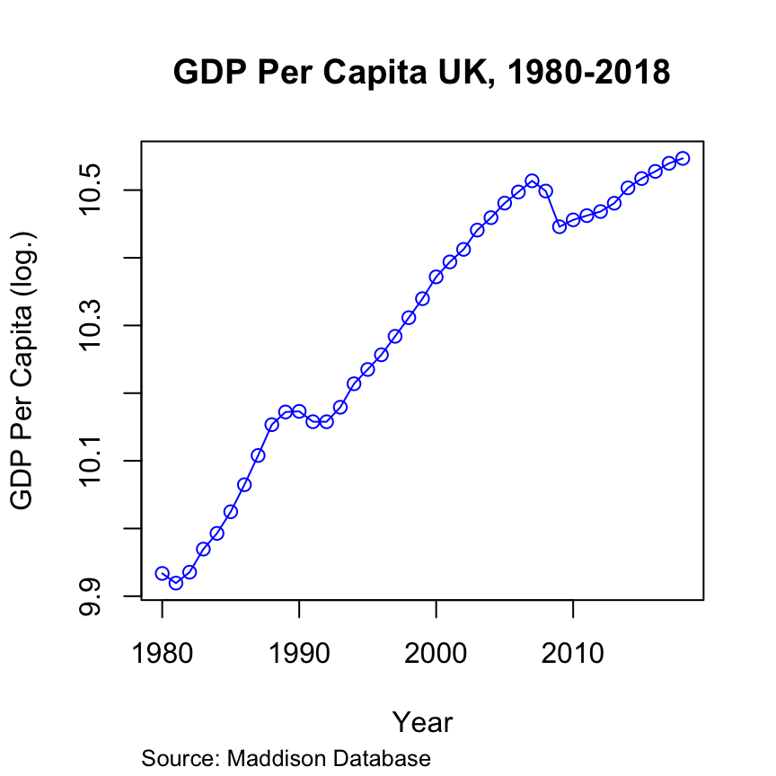